# KDAX vs KMUX: profile examples

**Blue: KDAX observed. Orange: KMUX observed. Dashed green: KMUX extrapolated using the with-AGL model.**

Left: simultaneous scans (within 3 minutes). Right: a lag based on measured flight speed and direction (within 3 minutes of that shifted time). Both columns use the same KMUX profile and axis scales. Heights are **metres above sea level**; times are **Pacific local time**. The night date refers to the evening.

Every displayed pair has measured flight directions within **30° of each other** and within **30° of the station axis**, with speeds ≥5 m/s and within a factor of two.

Gray shading is below KMUX’s lowest measured layer. The stations are 151 km apart, with KDAX’s antenna 1,038 m lower. These are regional comparisons, not measurements of exactly the same airspace.

Three sections show **upper-matched examples, upper-profile mismatches, and random high-migration examples**, with comparable flight directions and both scan matches available. Lower-layer model errors never determine selection. The matched group prioritizes upper agreement; the mismatch group prioritizes high KMUX upper-band intensity among cases failing that screen. All 40 nights and methods.

The random section samples three nights uniformly per season, then one eligible anchor uniformly within each night. Anchors must be in the upper quarter of that night’s higher-radar shared-band intensity, with both direction-matched scan comparisons available. Seed: 20261005. Random selection does not use agreement or model errors; examples may recur across sections.

# Upper-matched examples

## 2025-05-09 — Spring

KDAX movement: **16.3 m/s toward 360°**. KMUX: **12.9 m/s toward 340°**. Lag: **183 minutes**, with **KMUX first**.

Selection assessed the simultaneous upper profiles.

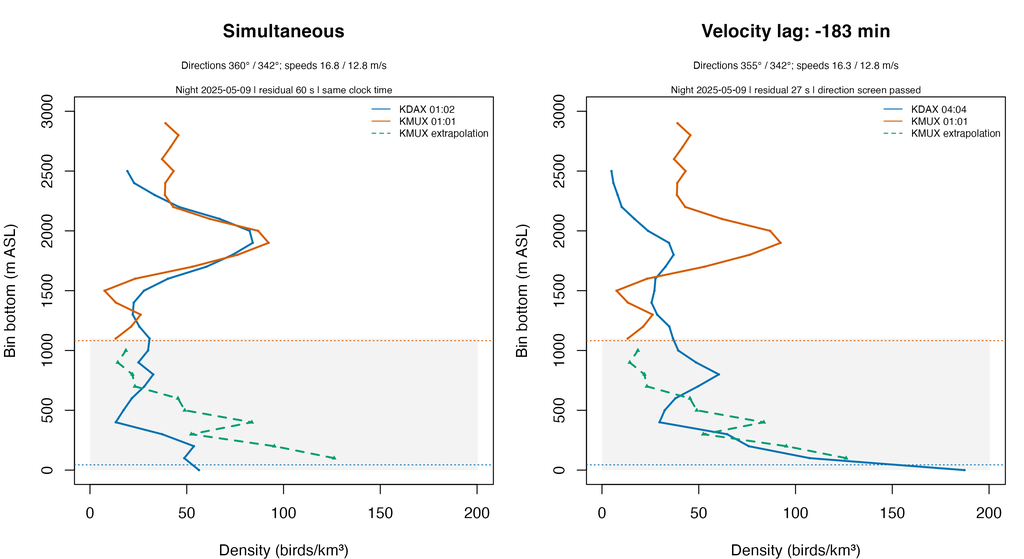

## 2018-05-08 — Spring

KDAX movement: **13.4 m/s toward 357°**. KMUX: **11.6 m/s toward 2°**. Lag: **203 minutes**, with **KMUX first**.

Selection assessed the simultaneous upper profiles.

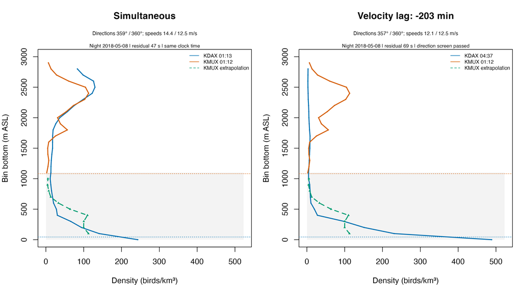

## 2022-05-04 — Spring

KDAX movement: **13.5 m/s toward 358°**. KMUX: **9.3 m/s toward 356°**. Lag: **225 minutes**, with **KMUX first**.

Selection assessed the velocity lag upper profiles.

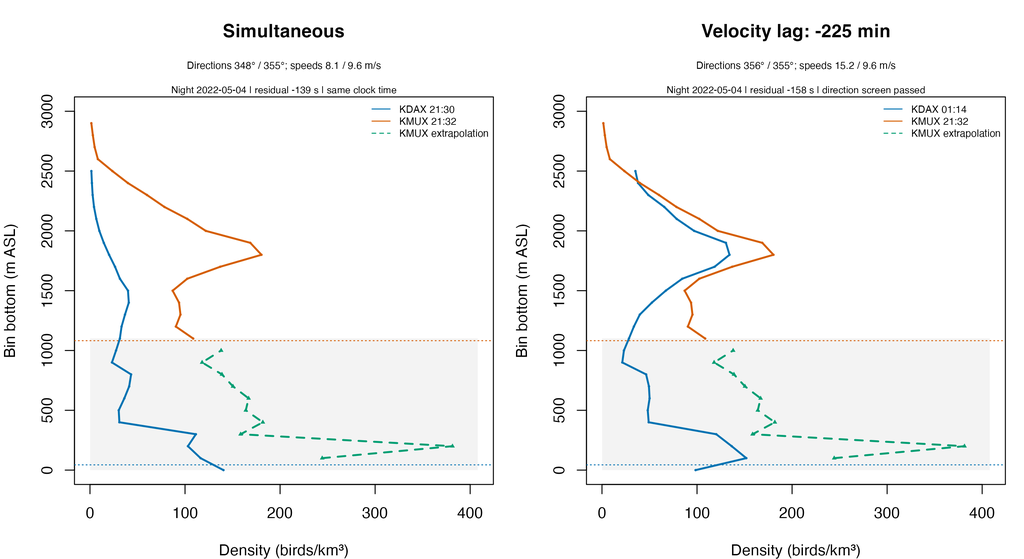

## 2025-10-03 — Fall

KDAX movement: **17.7 m/s toward 179°**. KMUX: **14.6 m/s toward 176°**. Lag: **158 minutes**, with **KDAX first**.

Selection assessed the velocity lag upper profiles.

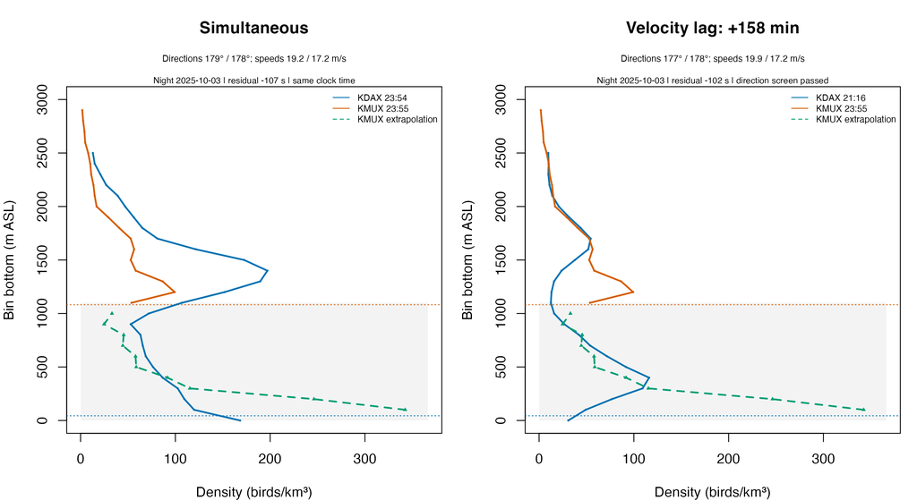

## 2021-10-09 — Fall

KDAX movement: **12.3 m/s toward 174°**. KMUX: **9.7 m/s toward 188°**. Lag: **232 minutes**, with **KDAX first**.

Selection assessed the simultaneous upper profiles.

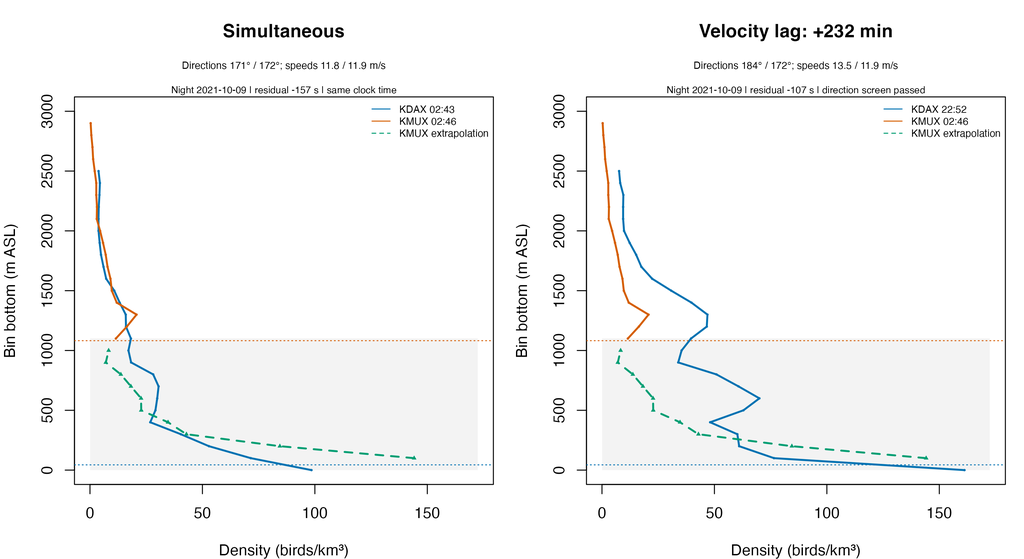

## 2025-10-15 — Fall

KDAX movement: **15.7 m/s toward 174°**. KMUX: **13.2 m/s toward 163°**. Lag: **184 minutes**, with **KDAX first**.

Selection assessed the simultaneous upper profiles.

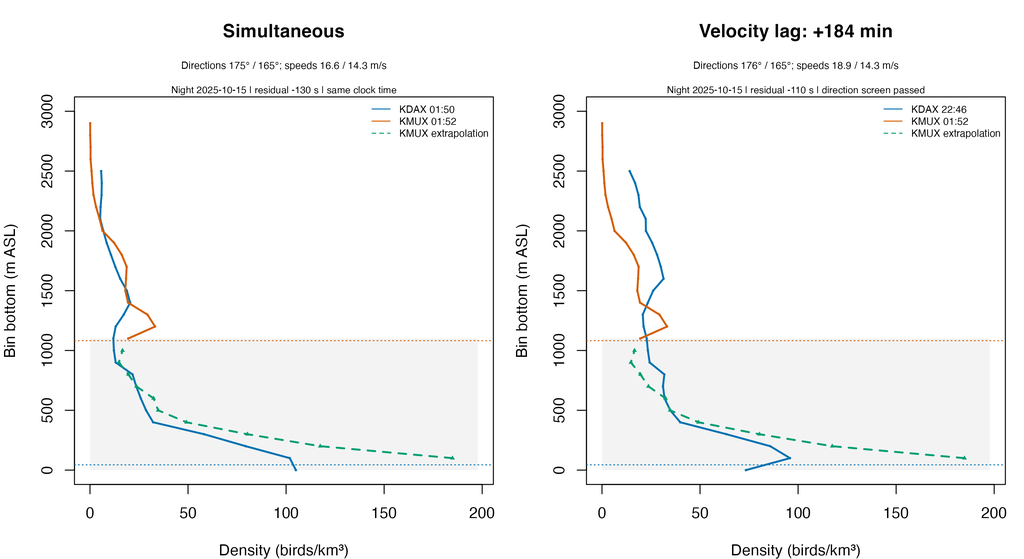

# Upper-profile mismatches

## 2014-04-30 — Spring

KDAX movement: **11.7 m/s toward 355°**. KMUX: **11.5 m/s toward 351°**. Lag: **224 minutes**, with **KMUX first**.

Selection assessed the simultaneous upper profiles.

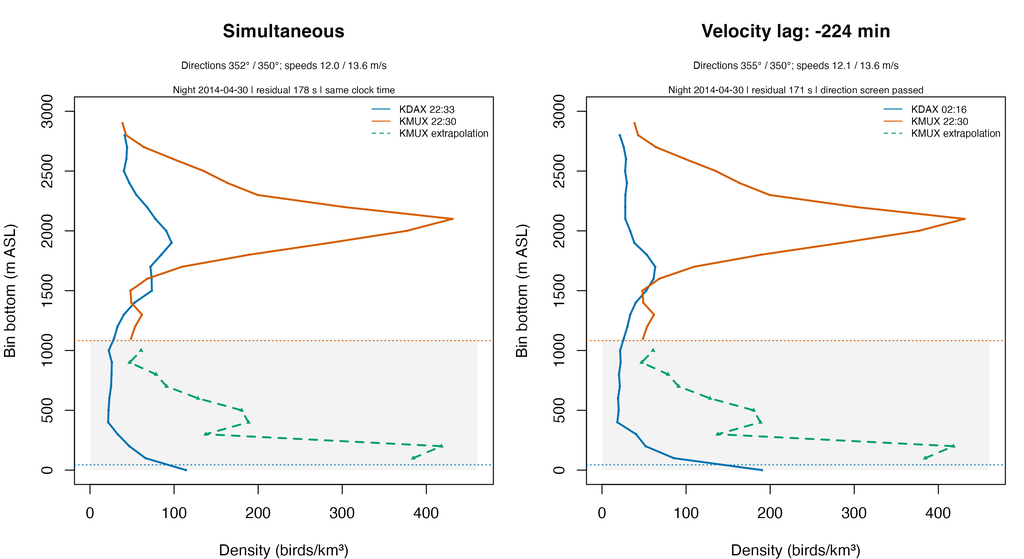

## 2019-04-18 — Spring

KDAX movement: **15.1 m/s toward 351°**. KMUX: **14.4 m/s toward 345°**. Lag: **181 minutes**, with **KMUX first**.

Selection assessed the simultaneous upper profiles.

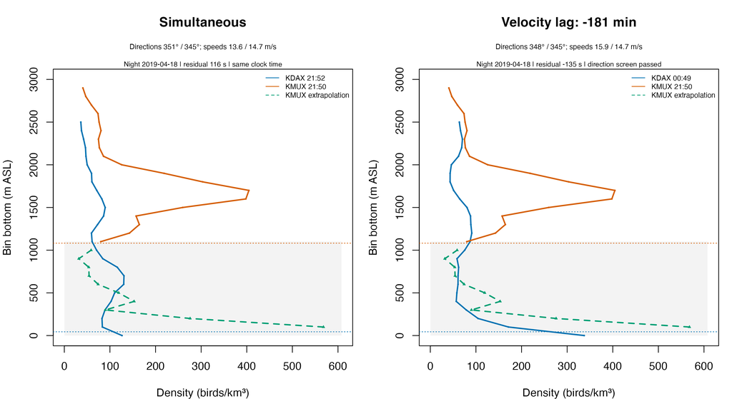

## 2018-05-04 — Spring

KDAX movement: **15.5 m/s toward 357°**. KMUX: **15.5 m/s toward 342°**. Lag: **172 minutes**, with **KMUX first**.

Selection assessed the simultaneous upper profiles.

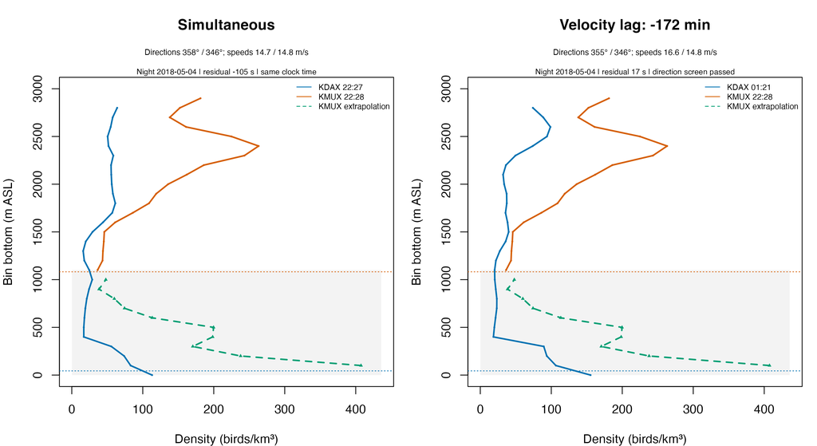

## 2021-10-27 — Fall

KDAX movement: **15.6 m/s toward 189°**. KMUX: **10.8 m/s toward 167°**. Lag: **196 minutes**, with **KDAX first**.

Selection assessed the simultaneous upper profiles.

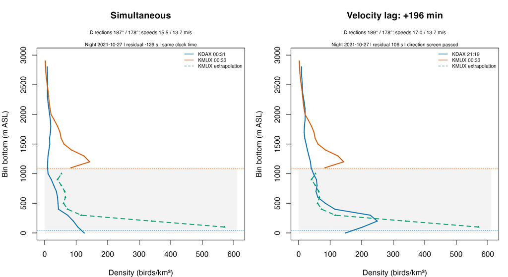

## 2020-10-11 — Fall

KDAX movement: **13.1 m/s toward 173°**. KMUX: **14.7 m/s toward 172°**. Lag: **187 minutes**, with **KDAX first**.

Selection assessed the simultaneous upper profiles.

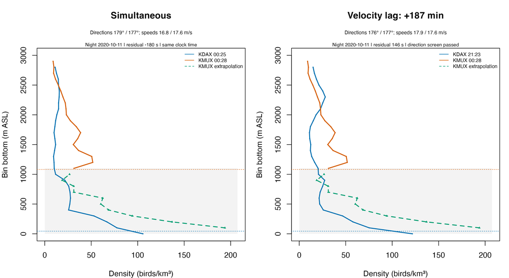

## 2018-10-06 — Fall

KDAX movement: **23.3 m/s toward 191°**. KMUX: **22.5 m/s toward 182°**. Lag: **110 minutes**, with **KDAX first**.

Selection assessed the simultaneous upper profiles.

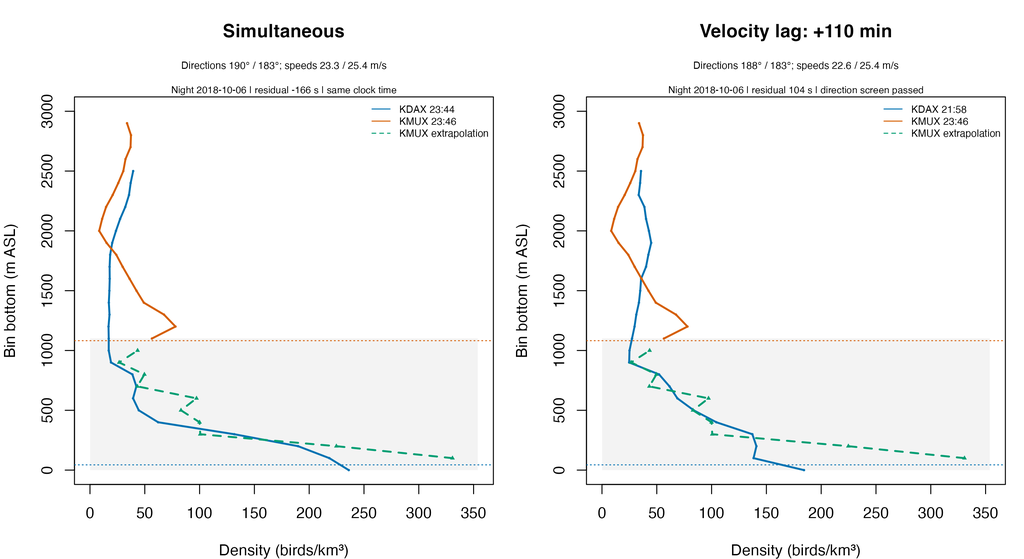

# Random high-migration examples

## 2016-05-03 — Spring

KDAX movement: **11.8 m/s toward 352°**. KMUX: **17.6 m/s toward 335°**. Lag: **192 minutes**, with **KMUX first**.

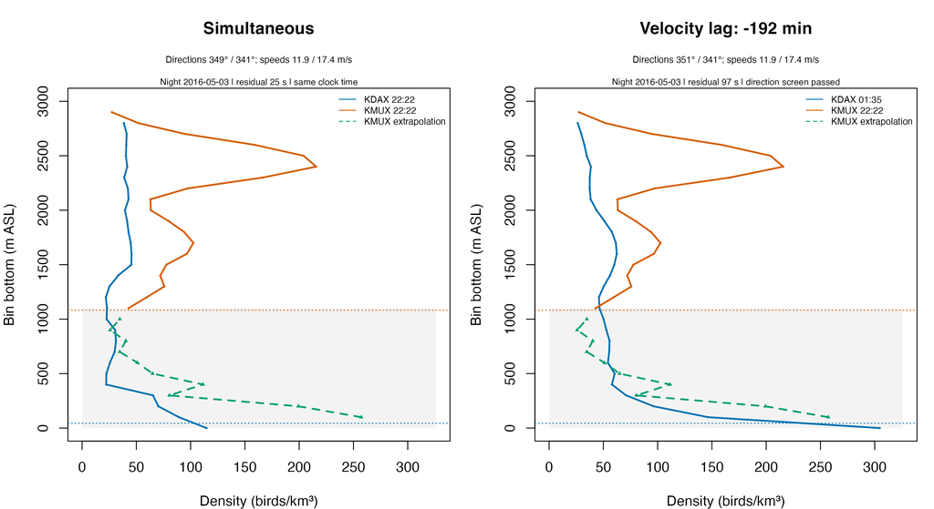

## 2016-04-17 — Spring

KDAX movement: **12.2 m/s toward 345°**. KMUX: **14.2 m/s toward 338°**. Lag: **213 minutes**, with **KMUX first**.

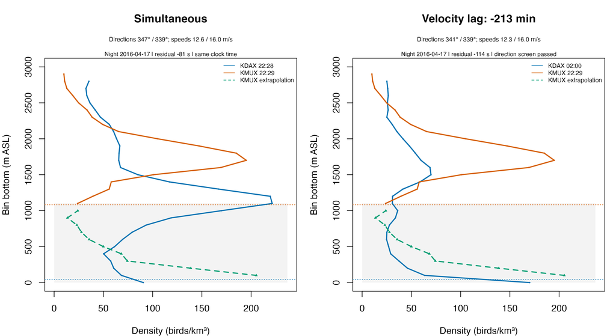

## 2018-05-04 — Spring

KDAX movement: **15.5 m/s toward 357°**. KMUX: **15.5 m/s toward 342°**. Lag: **172 minutes**, with **KMUX first**.

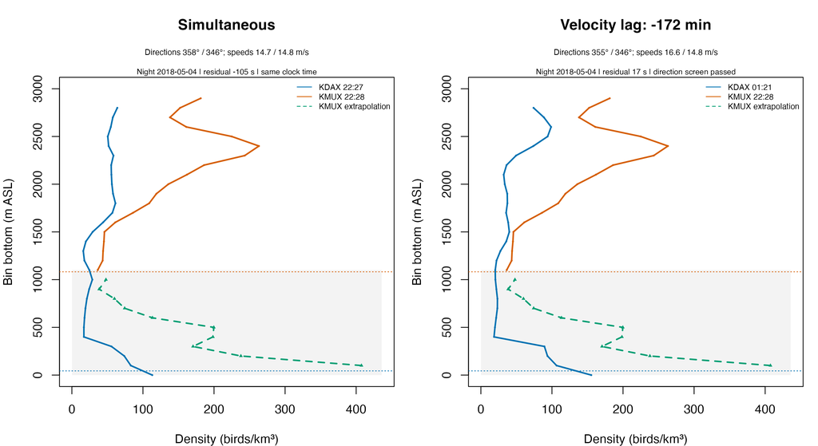

## 2019-09-19 — Fall

KDAX movement: **14.9 m/s toward 177°**. KMUX: **11.9 m/s toward 185°**. Lag: **190 minutes**, with **KDAX first**.

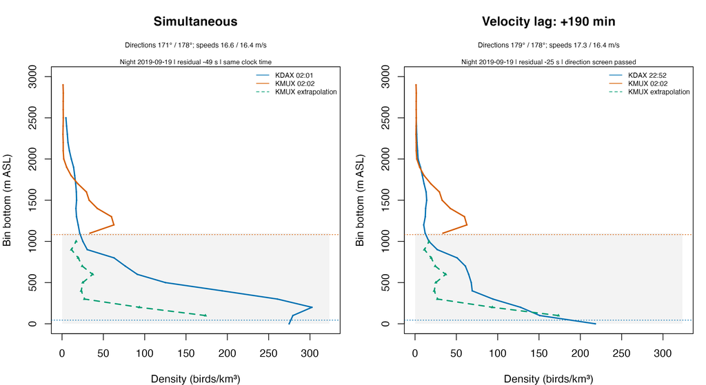

## 2017-09-30 — Fall

KDAX movement: **11.9 m/s toward 152°**. KMUX: **14.8 m/s toward 164°**. Lag: **216 minutes**, with **KDAX first**.

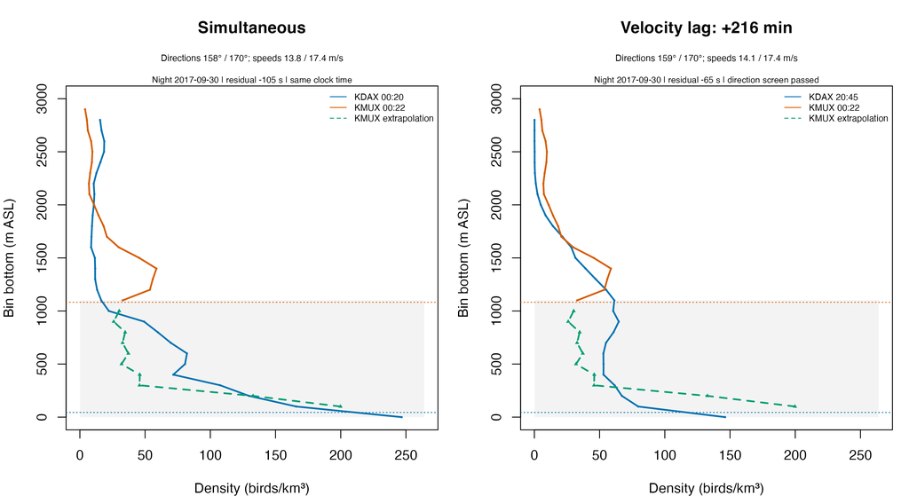

## 2021-10-27 — Fall

KDAX movement: **15.6 m/s toward 189°**. KMUX: **10.8 m/s toward 167°**. Lag: **196 minutes**, with **KDAX first**.

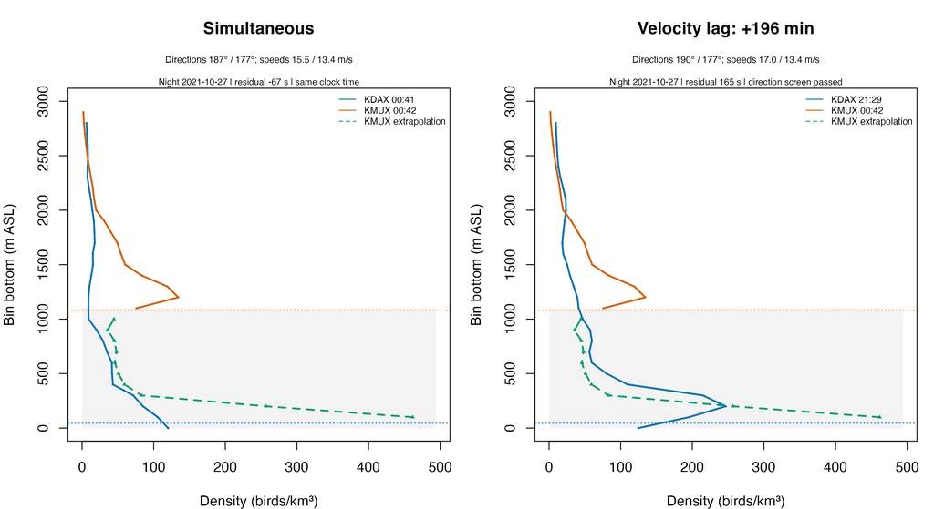

Reproduce locally with `Rscript analysis/kdax-kmux/render.R`. The RMarkdown, R plots, model predictions, matched timestamps, and source records are in this directory.